# HW 3

Alex Osterbuhr

2023-04-21

# Libraries

```r
library(tidyverse)
library(rpart)
library(caret)
library(performanceEstimation)
library(randomForest)
library(AUC)
library(broom)
```

# Part 1: Collect, Explore, and Prepare the Data

### Step 1

Import and preview the data. Call the dataset loans. Remember to use the tidyverse package as much as possible. This includes making use of the read_csv() functions when importing data. Use the glimpse() function to show that your data was imported properly.

```r
loans <- read_csv("https://s3.amazonaws.com/notredame.analytics.data/lendingclub.csv")
glimpse(loans)
```

```
## Rows: 42,445
## Columns: 19
## $ LoanAmount       <dbl> 5000, 2500, 2400, 10000, 3000, 5000, 7000, 3000, 5600…
## $ LoanTerm         <dbl> 36, 60, 36, 36, 60, 36, 60, 36, 60, 60, 60, 36, 36, 3…
## $ InterestRate     <dbl> 10.65, 15.27, 15.96, 13.49, 12.69, 7.90, 15.96, 18.64…
## $ Installment      <dbl> 162.87, 59.83, 84.33, 339.31, 67.79, 156.46, 170.08, …
## $ Grade            <chr> "B", "C", "C", "C", "B", "A", "C", "E", "F", "B", "C"…
## $ EmploymentLength <chr> "10+ years", "< 1 year", "10+ years", "10+ years", "1…
## $ HomeOwnership    <chr> "RENT", "RENT", "RENT", "RENT", "RENT", "RENT", "RENT…
## $ AnnualIncome     <dbl> 24000.00, 30000.00, 12252.00, 49200.00, 80000.00, 360…
## $ IncomeVerified   <chr> "Yes", "Yes", "No", "Yes", "Yes", "Yes", "No", "Yes",…
## $ LoanPurpose      <chr> "credit_card", "car", "small_business", "other", "oth…
## $ DTI              <dbl> 27.65, 1.00, 8.72, 20.00, 17.94, 11.20, 23.51, 5.35, …
## $ Delinquencies    <dbl> 0, 0, 0, 0, 0, 0, 0, 0, 0, 0, 0, 0, 0, 0, 0, 0, 0, 0,…
## $ Inquiries        <dbl> 1, 5, 2, 1, 0, 3, 1, 2, 2, 0, 2, 0, 1, 2, 2, 1, 2, 0,…
## $ OpenAccounts     <dbl> 3, 3, 2, 10, 15, 9, 7, 4, 11, 2, 14, 12, 4, 11, 14, 1…
## $ TotalAccounts    <dbl> 9, 4, 10, 37, 38, 12, 11, 4, 13, 3, 23, 34, 9, 11, 29…
## $ PublicRecords    <dbl> 0, 0, 0, 0, 0, 0, 0, 0, 0, 0, 0, 0, 0, 0, 0, 0, 0, 0,…
## $ RevolvingCredit  <dbl> 13648, 1687, 2956, 5598, 27783, 7963, 17726, 8221, 52…
## $ CreditUtilized   <dbl> 83.70, 9.40, 98.50, 21.00, 53.90, 28.30, 85.60, 87.50…
## $ Default          <chr> "No", "Yes", "No", "No", "No", "No", "No", "No", "Yes…
```

##### Bringing in the initial data and glimpsing per instruction.

### Step 2

You notice that the Grade, EmploymentLength, HomeOwnership, IncomeVerified, LoanPurpose, and Default features were imported as string values. Convert these features to factors. Use the glimpse() function to show that your conversion worked

```r
loans <- loans %>%
  mutate(across(c(Grade, EmploymentLength, HomeOwnership, IncomeVerified, LoanPurpose, Default), ~as.factor(.)))
glimpse(loans)
```

```
## Rows: 42,445
## Columns: 19
## $ LoanAmount       <dbl> 5000, 2500, 2400, 10000, 3000, 5000, 7000, 3000, 5600…
## $ LoanTerm         <dbl> 36, 60, 36, 36, 60, 36, 60, 36, 60, 60, 60, 36, 36, 3…
## $ InterestRate     <dbl> 10.65, 15.27, 15.96, 13.49, 12.69, 7.90, 15.96, 18.64…
## $ Installment      <dbl> 162.87, 59.83, 84.33, 339.31, 67.79, 156.46, 170.08, …
## $ Grade            <fct> B, C, C, C, B, A, C, E, F, B, C, B, C, B, B, D, C, A,…
## $ EmploymentLength <fct> 10+ years, < 1 year, 10+ years, 10+ years, 1 year, 3 …
## $ HomeOwnership    <fct> RENT, RENT, RENT, RENT, RENT, RENT, RENT, RENT, OWN, …
## $ AnnualIncome     <dbl> 24000.00, 30000.00, 12252.00, 49200.00, 80000.00, 360…
## $ IncomeVerified   <fct> Yes, Yes, No, Yes, Yes, Yes, No, Yes, Yes, Yes, No, Y…
## $ LoanPurpose      <fct> credit_card, car, small_business, other, other, weddi…
## $ DTI              <dbl> 27.65, 1.00, 8.72, 20.00, 17.94, 11.20, 23.51, 5.35, …
## $ Delinquencies    <dbl> 0, 0, 0, 0, 0, 0, 0, 0, 0, 0, 0, 0, 0, 0, 0, 0, 0, 0,…
## $ Inquiries        <dbl> 1, 5, 2, 1, 0, 3, 1, 2, 2, 0, 2, 0, 1, 2, 2, 1, 2, 0,…
## $ OpenAccounts     <dbl> 3, 3, 2, 10, 15, 9, 7, 4, 11, 2, 14, 12, 4, 11, 14, 1…
## $ TotalAccounts    <dbl> 9, 4, 10, 37, 38, 12, 11, 4, 13, 3, 23, 34, 9, 11, 29…
## $ PublicRecords    <dbl> 0, 0, 0, 0, 0, 0, 0, 0, 0, 0, 0, 0, 0, 0, 0, 0, 0, 0,…
## $ RevolvingCredit  <dbl> 13648, 1687, 2956, 5598, 27783, 7963, 17726, 8221, 52…
## $ CreditUtilized   <dbl> 83.70, 9.40, 98.50, 21.00, 53.90, 28.30, 85.60, 87.50…
## $ Default          <fct> No, Yes, No, No, No, No, No, No, Yes, Yes, No, No, Ye…
```

##### Mutated called out features as factors as we have done in past assignments as well.

### Step 3

Get descriptive statistics for entire dataset

```r
summary(loans)
```

```
##    LoanAmount       LoanTerm      InterestRate    Installment      Grade
##  Min.   :  500   Min.   :36.00   Min.   : 5.42   Min.   :  15.67   A:10171
##  1st Qu.: 5200   1st Qu.:36.00   1st Qu.: 9.63   1st Qu.: 165.74   B:12376
##  Median : 9800   Median :36.00   Median :11.99   Median : 278.15   C: 8719
##  Mean   :11103   Mean   :42.22   Mean   :12.16   Mean   : 322.98   D: 5996
##  3rd Qu.:15000   3rd Qu.:60.00   3rd Qu.:14.72   3rd Qu.: 428.64   E: 3380
##  Max.   :35000   Max.   :60.00   Max.   :24.59   Max.   :1305.19   F: 1294
##                                                                    G:  509
##   EmploymentLength  HomeOwnership    AnnualIncome     IncomeVerified
##  10+ years: 9365   MORTGAGE:18938   Min.   :   1896   No :18691
##  < 1 year : 5029   NONE    :    4   1st Qu.:  40000   Yes:23754
##  2 years  : 4736   OTHER   :  134   Median :  59000
##  3 years  : 4358   OWN     : 3243   Mean   :  69169
##  4 years  : 3640   RENT    :20126   3rd Qu.:  82500
##  1 year   : 3584                    Max.   :6000000
##  (Other)  :11733
##              LoanPurpose         DTI        Delinquencies       Inquiries
##  debt_consolidation:19759   Min.   : 0.00   Min.   : 0.0000   Min.   : 0.000
##  credit_card       : 5474   1st Qu.: 8.21   1st Qu.: 0.0000   1st Qu.: 0.000
##  other             : 4383   Median :13.48   Median : 0.0000   Median : 1.000
##  home_improvement  : 3194   Mean   :13.38   Mean   : 0.1525   Mean   : 1.081
##  major_purchase    : 2304   3rd Qu.:18.69   3rd Qu.: 0.0000   3rd Qu.: 2.000
##  small_business    : 1991   Max.   :29.99   Max.   :13.0000   Max.   :33.000
##  (Other)           : 5340
##   OpenAccounts    TotalAccounts   PublicRecords     RevolvingCredit
##  Min.   : 1.000   Min.   : 1.00   Min.   :0.00000   Min.   :      0
##  1st Qu.: 6.000   1st Qu.:13.00   1st Qu.:0.00000   1st Qu.:   3665
##  Median : 9.000   Median :20.00   Median :0.00000   Median :   8847
##  Mean   : 9.351   Mean   :22.14   Mean   :0.05819   Mean   :  14320
##  3rd Qu.:12.000   3rd Qu.:29.00   3rd Qu.:0.00000   3rd Qu.:  17268
##  Max.   :47.000   Max.   :90.00   Max.   :5.00000   Max.   :1207359
##
##  CreditUtilized   Default
##  Min.   :  0.00   No :36036
##  1st Qu.: 25.70   Yes: 6409
##  Median : 49.70
##  Mean   : 49.12
##  3rd Qu.: 72.70
##  Max.   :119.00
##
```

##### Used summary() to gain descriptive stats for data

### Step 4

Split your dataset into training and test sets using stratified random sampling (with Default as the stratum). Assign 75% of your original data to the training set and 25% to the test set. Call the training set, loans_train, and the test set, loans_test. Use ‘1234’ for your seed and don’t forget to use the RNGkind() function.

```r
RNGkind(sample.kind = "Rounding")
set.seed(1234)
loans_sample <- createDataPartition(y = loans$Default,
                                   p = .75,
                                   list = FALSE)
loans_train <- loans[loans_sample, ]
loans_test <- loans[-loans_sample, ]
```

##### Created a sample set from loans. Assigned sample set to my training data and took away sample set from test data so that we can train off of the sample and correctly test against the test set.

### Step 5

Based on the descriptive statistics of the loans dataset, you notice that the dataset suffers from class imbalance. Use the smote() function from the performanceEstimation package to balance (50-50) the training set. Use ‘1234’ for your seed here as well and don’t forget to use the RNGkind() function.

```r
RNGkind(sample.kind = "Rounding")
set.seed(1234)
loans_train <- smote(Default~., loans_train,
                     perc.over = 1,
                     perc.under = 2)
```

##### Using smote() the training set is now balanced 50/50 on Default

### Step 6

During the recursive partitioning process, decision trees attempt to create a split using different values for a feature. You notice that the values for the Delinquencies, Inquiries, OpenAccounts, TotalAccounts, and PublicRecords features are double-precision values. This means that the decision tree could split on OpenAccounts <= 1.4. This makes no sense since a borrower cannot have 1.4 open accounts. To resolve this potential issue, convert these features to integers for both the training and test sets. Use the glimpse() function to show that your conversion worked.

```r
loans_test <- loans_test %>%
  mutate(across(c(Delinquencies, Inquiries, OpenAccounts, TotalAccounts, PublicRecords), ~as.integer(.)))
loans_train <- loans_train %>%
  mutate(across(c(Delinquencies, Inquiries, OpenAccounts, TotalAccounts, PublicRecords), ~as.integer(.)))
glimpse(loans_test)
```

```
## Rows: 10,611
## Columns: 19
## $ LoanAmount       <dbl> 2400, 10000, 3000, 5000, 3000, 5375, 12000, 3000, 100…
## $ LoanTerm         <dbl> 36, 36, 60, 36, 36, 60, 36, 36, 36, 60, 36, 60, 36, 3…
## $ InterestRate     <dbl> 15.96, 13.49, 12.69, 7.90, 18.64, 12.69, 12.69, 9.91,…
## $ Installment      <dbl> 84.33, 339.31, 67.79, 156.46, 109.43, 121.45, 402.54,…
## $ Grade            <fct> C, C, B, A, E, B, B, B, D, D, B, C, C, B, B, A, D, A,…
## $ EmploymentLength <fct> 10+ years, 10+ years, 1 year, 3 years, 9 years, < 1 y…
## $ HomeOwnership    <fct> RENT, RENT, RENT, RENT, RENT, RENT, OWN, RENT, RENT, …
## $ AnnualIncome     <dbl> 12252, 49200, 80000, 36000, 48000, 15000, 75000, 1500…
## $ IncomeVerified   <fct> No, Yes, Yes, Yes, Yes, Yes, Yes, Yes, No, No, Yes, Y…
## $ LoanPurpose      <fct> small_business, other, other, wedding, car, other, de…
## $ DTI              <dbl> 8.72, 20.00, 17.94, 11.20, 5.35, 18.08, 10.78, 12.56,…
## $ Delinquencies    <int> 0, 0, 0, 0, 0, 0, 0, 0, 0, 3, 0, 0, 0, 0, 0, 0, 0, 0,…
## $ Inquiries        <int> 2, 1, 0, 3, 2, 0, 0, 2, 1, 0, 0, 1, 1, 2, 0, 0, 0, 0,…
## $ OpenAccounts     <int> 2, 10, 15, 9, 4, 2, 12, 11, 11, 14, 8, 11, 6, 9, 7, 1…
## $ TotalAccounts    <int> 10, 37, 38, 12, 4, 3, 34, 11, 23, 22, 12, 31, 6, 12, …
## $ PublicRecords    <int> 0, 0, 0, 0, 0, 0, 0, 0, 0, 0, 0, 0, 0, 0, 0, 0, 0, 0,…
## $ RevolvingCredit  <dbl> 2956, 5598, 27783, 7963, 8221, 9279, 23336, 7323, 652…
## $ CreditUtilized   <dbl> 98.5, 21.0, 53.9, 28.3, 87.5, 36.5, 67.1, 43.1, 81.5,…
## $ Default          <fct> No, No, No, No, No, Yes, No, No, No, Yes, No, No, No,…
```

```r
glimpse(loans_train)
```

```
## Rows: 19,228
## Columns: 19
## $ LoanAmount       <dbl> 1500, 24250, 17500, 1500, 35000, 18000, 10000, 14000,…
## $ LoanTerm         <dbl> 36, 60, 36, 36, 60, 60, 36, 36, 36, 36, 36, 60, 36, 6…
## $ InterestRate     <dbl> 7.29, 23.91, 13.48, 10.99, 17.99, 13.06, 12.73, 7.51,…
## $ Installment      <dbl> 46.52, 519.76, 593.70, 49.11, 888.58, 410.11, 335.67,…
## $ Grade            <fct> A, G, C, B, E, C, C, A, A, B, B, B, A, A, A, E, A, C,…
## $ EmploymentLength <fct> < 1 year, 7 years, 10+ years, < 1 year, 9 years, 5 ye…
## $ HomeOwnership    <fct> RENT, MORTGAGE, MORTGAGE, RENT, RENT, RENT, MORTGAGE,…
## $ AnnualIncome     <dbl> 30000.0, 120000.0, 73200.0, 33996.0, 115000.0, 56000.…
## $ IncomeVerified   <fct> Yes, Yes, No, No, Yes, Yes, Yes, No, No, Yes, No, Yes…
## $ LoanPurpose      <fct> debt_consolidation, debt_consolidation, credit_card, …
## $ DTI              <dbl> 3.40, 12.96, 3.31, 16.13, 13.11, 23.25, 17.40, 18.44,…
## $ Delinquencies    <int> 0, 0, 0, 0, 0, 0, 1, 0, 0, 0, 0, 0, 0, 0, 0, 1, 0, 0,…
## $ Inquiries        <int> 0, 3, 0, 2, 0, 3, 0, 1, 1, 0, 0, 0, 1, 0, 0, 0, 0, 2,…
## $ OpenAccounts     <int> 3, 7, 4, 5, 12, 10, 8, 14, 8, 7, 12, 14, 11, 8, 13, 1…
## $ TotalAccounts    <int> 4, 20, 12, 14, 36, 20, 20, 43, 18, 13, 30, 39, 21, 16…
## $ PublicRecords    <int> 0, 0, 1, 0, 0, 0, 0, 0, 0, 1, 0, 0, 0, 0, 0, 0, 0, 0,…
## $ RevolvingCredit  <dbl> 1669, 31992, 9578, 3641, 13683, 15265, 29476, 12241, …
## $ CreditUtilized   <dbl> 11.9, 99.0, 37.0, 41.4, 48.2, 51.6, 57.6, 24.0, 6.0, …
## $ Default          <fct> No, No, No, No, No, No, No, No, No, No, No, No, No, N…
```

##### First mutated back in step 2 but found this only continued to mutate my test data and not my training data. Thought that would be more efficient but thankfully noticed that issue as there was no error. Used same mutate() code and reassigned to train and test data as we did in step 2.

# Part 2: Train the Models

### Step 1

Use the train() function from the caret package to train a model based on the CART decision tree algorithm. Use 3-fold cross-validation as the resampling technique and Kappa as the performance metric. During grid search, choose the optimal complexity parameter from among the following - 0.0001, 0.0002, 0.0003, 0.0004, 0.0005, 0.0006, 0.0007, 0.0008, 0.0009, and 0.001

```r
grid <- expand.grid(
  cp = seq(from = .0001, to = .001, by = .0001)
)
loans_mod <- train(
  Default~.,
  data = loans_train,
  metric = "Kappa",
  method = "rpart",
  trControl = trainControl(method = "cv", number=3),
  tuneGrid = grid)
loans_mod
```

```
## CART
##
## 19228 samples
##    18 predictor
##     2 classes: 'No', 'Yes'
##
## No pre-processing
## Resampling: Cross-Validated (3 fold)
## Summary of sample sizes: 12818, 12819, 12819
## Resampling results across tuning parameters:
##
##   cp     Accuracy   Kappa
##   1e-04  0.6413561  0.2827109
##   2e-04  0.6459327  0.2918639
##   3e-04  0.6512894  0.3025778
##   4e-04  0.6514455  0.3028928
##   5e-04  0.6543582  0.3087174
##   6e-04  0.6561264  0.3122515
##   7e-04  0.6566985  0.3133948
##   8e-04  0.6548782  0.3097570
##   9e-04  0.6526419  0.3052851
##   1e-03  0.6503015  0.3006030
##
## Kappa was used to select the optimal model using the largest value.
## The final value used for the model was cp = 7e-04.
```

##### Created a grid with sequence of numbers given in instructions. Then created a model using rpart as the method for a CART decision tree.

### Step 2

Use the train() function from the caret package to train a second model based on the Random Forest (rf) algorithm. Use 3-fold cross-validation as the resampling technique and Kappa as the performance metric. During grid search, choose the number of randomly selected predictors from among the following - 10, 12, and 14.

```r
preds <- c(10, 12, 14)
random_grid <- expand.grid(mtry = preds)
rf_mod <- train(
  Default ~ .,
  data = loans_train,
  metric = "Kappa",
  method = "rf",
  trControl = trainControl(method = "cv", number = 3),
  tuneGrid = random_grid
)
rf_mod
```

```
## Random Forest
##
## 19228 samples
##    18 predictor
##     2 classes: 'No', 'Yes'
##
## No pre-processing
## Resampling: Cross-Validated (3 fold)
## Summary of sample sizes: 12819, 12818, 12819
## Resampling results across tuning parameters:
##
##   mtry  Accuracy   Kappa
##   10    0.7552006  0.5104018
##   12    0.7554084  0.5108172
##   14    0.7543164  0.5086330
##
## Kappa was used to select the optimal model using the largest value.
## The final value used for the model was mtry = 12.
```

##### Just like last step, I created a grid but used mtry since Random Forest or ‘rf’ is to be used as the method.

### Step 3

Use the train() function from the caret package to train a third model based on the eXtreme Gradient Boosting (xgbTree) algorithm. Use 3-fold cross-validation as the resampling technique and Kappa as the performance metric. This algorithm has seven tunable hyperparameters: ● Maximum Tree Depth: set this to 6. ● Minimum Loss Reduction: set this to 0.01. ● Minimum Sum of Instance Weights: set this to 1. ● Number of Boosting Iterations: set this to 100. ● Shrinkage (Learning Rate): evaluate values between 0.1 and 0.5 by increments of 0.05. ● Subsample Percentage: set this to 1. ● Subsample Ratio of Columns: set this to 1.

```r
xg_grid <- expand.grid(max_depth = 6,
                       gamma = .01,
                       min_child_weight = 1,
                       nrounds = 100,
                       eta = seq(from=.1, to=.5, by=.05),
                       subsample = 1,
                       colsample_bytree = 1)
xg_mod <- train(
  Default ~ .,
  data = loans_train,
  metric = "Kappa",
  method = "xgbTree",
  trControl = trainControl(method = "cv", number = 3),
  tuneGrid = xg_grid

)
xg_mod
```

[output not shown]

##### Created a grid using values given for using an Extreme Gradient Boost as the method for my model.

# Part 3

### Step 1

Create and display a table with the numeric performance metrics for each model. The metrics in the table should include Accuracy, Kappa, Sensitivity, Specificity, Precision, Recall, F-Measure, and Area Under the Curve.

```r
num_metrics <- function(model, data, labels, value, method){
  library(AUC)
  library(broom)
  curve <- predict(model, data, type = 'prob') %>%
    pull(value) %>%
    roc(pull(data, labels))
  metric <- predict(model, data) %>%
    confusionMatrix(pull(data,labels), positive=value) %>%
    tidy() %>%
    filter(term %in% c('accuracy', 'kappa', 'sensitivity', 'specificity', 'precision', 'recall', 'f1', 'AUC')) %>%
    select(term, estimate) %>%
    pivot_wider(names_from = term, values_from = estimate) %>%
    mutate(approach = method) %>%
    mutate(auc = auc(curve)) %>%
    select(approach, everything())
}

m_1 <- num_metrics(loans_mod, loans_test, 'Default', 'Yes', 'Decision Tree (CART)')
m_2 <- num_metrics(rf_mod, loans_test, 'Default', 'Yes', 'Random Forest')
m_3 <- num_metrics(xg_mod, loans_test, 'Default', 'Yes', 'Extreme Gradient Boosting')
metric_table <- bind_rows(m_1,m_2,m_3)
metric_table
```

```
## # A tibble: 3 × 9
##   approach              accur…¹ kappa sensi…² speci…³ preci…⁴ recall    f1   auc
##   <chr>                   <dbl> <dbl>   <dbl>   <dbl>   <dbl>  <dbl> <dbl> <dbl>
## 1 Decision Tree (CART)    0.621 0.131   0.598   0.625   0.221  0.598 0.323 0.648
## 2 Random Forest           0.645 0.157   0.605   0.652   0.236  0.605 0.340 0.682
## 3 Extreme Gradient Boo…   0.666 0.148   0.537   0.689   0.235  0.537 0.327 0.660
## # … with abbreviated variable names ¹accuracy, ²sensitivity, ³specificity,
## #   ⁴precision
```

##### Created a function as we have done in class for pulling metric values. Added ‘AUC’ which we did not do in class. Then used function to gather the metrics for all three of the previously built models and built a table by row binding.

### Step 2

Based solely on the numeric performance metrics, which model would you choose and why?

##### I would choose Random Forest. All models we built on the Kappa metric. This model has the best Kappa metric. It also has the largest AUC. Where it doesn’t have the high on each metric, looking at the totality and weight of the mentioned metrics vs others, that seems best.

### Step 3

Plot ROC curves for each of the three models on the same chart.

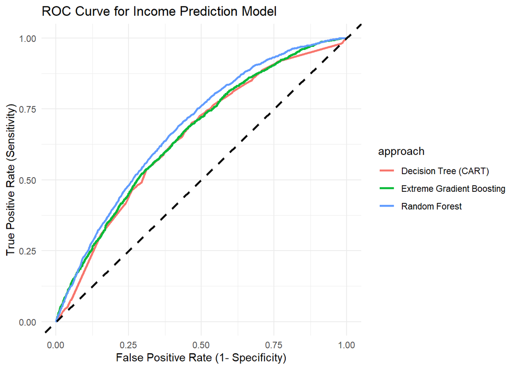

```r
viz_metrics <- function(model, data, labels, value, method){
  library(AUC)
  library(broom)

  metric <- predict(model, data, type = "prob") %>%
    pull(value) %>%
    roc(pull(data, labels)) %>%
    tidy() %>%
    mutate(approach = method) %>%
    select(approach, everything())

  return (metric)
}

v_1 <- viz_metrics(loans_mod, loans_test, 'Default', 'Yes', 'Decision Tree (CART)')
v_2 <- viz_metrics(rf_mod, loans_test, 'Default', 'Yes', 'Random Forest')
v_3 <- viz_metrics(xg_mod, loans_test, 'Default', 'Yes', 'Extreme Gradient Boosting')
total_viz <- bind_rows(v_1,v_2,v_3)
total_viz %>%
  ggplot(mapping  = aes(x = fpr, y = tpr, color = approach)) +
  geom_line(size = 1) +
  geom_abline(intercept = 0, slope = 1, color = "black", linetype = "dashed", size = 1) +
  xlim(0, 1) +
  labs(title = "ROC Curve for Income Prediction Model",
       x = "False Positive Rate (1- Specificity)",
       y = "True Positive Rate (Sensitivity)") +
  theme_minimal()
```

##### Using a visualization code covered in class for ROC and AUC, I plotted the three models by using the viz_metric function created in the code, assigning that function against all three models, and then creating a table as in the previous step only on these viz metrics. The plot shows the values from that table.

### Step 4

Based on the numeric performance metrics and the ROC curves, which model would you choose and why?

##### Looking at the ROC visualization, it still supports using Random Forest using the metrics as stated and the AOC in the viz as well.